# BCB420 Computational System Biology

Assignment 1: Data set selection and initial Processing

Yuxi Zhu

2025-02-11

First, we want to load all the library used, including limma [1], edgeR [2], knitr for report generation [3], and ggplot2 for visualization [4], biomaRt [5] and GEOquery [6].

```r
library(GEOquery)
library(limma)
library(edgeR)
library(dplyr)
library(biomaRt)
library(knitr)
library(ggplot2)
```

## Select an Expression Data Set

I am primarily interested in PDAC research and I am curious in looking at it from the genomic perspective [7]. I went on GEO and search PDAC with filters: Homo sapiens, Expression profiling by high throughput sequencing, Publication date from 2020/01/01 to 2025/12/31, Sample count from 5 to 100, TXT [8]. I was able to narrow down the search into 34 datasets. I manually went through most of it and finalize on the dataset GSE226448. It has 4 different conditions and performed under 3 biological replicates for each. It is performed using Illumina NovaSeq 6000 and it is also newly published in 2024. We first download the dataset and analyze using GEOquery [6].

```r
data_geoid <- "GSE226448"
gse <- getGEO(data_geoid, GSEMatrix=FALSE)
```

Here are the summary of the dataset. The pancreatic cancer tumor microenvironment is dominated primarily by cancer-associated fibroblasts (CAFs) and tumor associated macrophages (TAMs). The interecellular dialogue between CAFs and TAMs and the resulting impact on chemoresistance, specifically to Folfirinox, remains poorly understood. In this study, we sought to understand the impact of primary PDAC CAFs on macrophage reprogramming in a folfirinox-dependent manner and performed various cellular assays (viability, immunophenotyping, phagocytosis, secretory profile analysis) and transcriptomic analysis.

Additional data exploration.

```r
current_gpl <- names(GPLList(gse))[[1]]
current_gpl_info <- Meta(getGEO(current_gpl))
```

Here are the additional information regarding the dataset.

Platform: Illumina NovaSeq 6000 (Homo sapiens)

Organism: Homo sapiens

The data processing indicates that the dataset from the supplementary file contains gene-level count values for each sample that is proprocessed, aligned and quantified.

```r
gse@gsms[[1]]@header$data_processing
```

```
## [1] "Trimming - Removal of adaptater sequences, removal of bases with Phread < 30."
## [2] "Alignment on reference genome with Subread using subread-align (v1.5.0) (1) with default parameters."
## [3] "Summarization at the gene level using featurecount."
## [4] "RPKM were calculated by count normalisaiton by gene length and library size."
## [5] "Assembly: hg38"
## [6] "Supplementary files format and content: tab-delimited text file includes count values for each Sample at the gene level."
```

## Clean the data and map to HUGO symbols

### 1-Downloading the data

The filename for the dataset which contains the count are obtained. There are only 1 file in the supplementary files and it is also the raw count RNA seq data.

```r
sfilenames <- GEOquery::getGEOSuppFiles(data_geoid, fetch_files=FALSE)
data_filename <- sfilenames$fname[1]
```

We will download the first file if neccessary.

```r
download_dir <- file.path(getwd())
missing_files <- sfilenames$fname[!file.exists(file.path(download_dir, data_geoid, sfilenames$fname[1]))]
if(length(missing_files) >0){
  for(i in 1:length(missing_files)){
  sfiles = getGEOSuppFiles(data_geoid,
  filter_regex = missing_files[i],
  baseDir = download_dir,
  fetch_files = TRUE)
  }
}
```

### 2 - Assess …

It contains 60660 rows of gene, which should be a good length for RNA seq dataset as shown in lecture.

```r
mc_seq_data <- read.table(
  file.path(download_dir,data_geoid,data_filename),
  header=TRUE,
  check.names=FALSE)
dim(mc_seq_data)[1]
```

```
## [1] 60660
```

```r
mc_seq_data_accessed <- mc_seq_data[-c(2, 3, 4, 5, 6)]
rownames(mc_seq_data_accessed) <- mc_seq_data_accessed$Geneid
mc_seq_data_accessed$Geneid <- NULL
colnames(mc_seq_data_accessed) <- gsub("03aln/bam/|\\.map\\.sort\\.bam", "", colnames(mc_seq_data_accessed))
kable(mc_seq_data_accessed[1:5, 1:5],format="html")
```

|  | M2-CAF_CTRL_rep1 | M2-CAF_CTRL_rep2 | M2-CAF_CTRL_rep3 | M2-CAF_FOLFI_rep1 | M2-CAF_FOLFI_rep2 |
| --- | --- | --- | --- | --- | --- |
| ENSG00000223972.5 | 0 | 0 | 0 | 0 | 0 |
| ENSG00000227232.5 | 75 | 91 | 103 | 86 | 95 |
| ENSG00000278267.1 | 1 | 1 | 1 | 2 | 1 |
| ENSG00000243485.5 | 0 | 0 | 0 | 0 | 0 |
| ENSG00000284332.1 | 0 | 0 | 0 | 0 | 0 |

The boxplot shows the distribution of raw counts in each dataset. This is expected for raw counts in RNA seq dataset as many genes are not expressed and only few genes are high expressed.

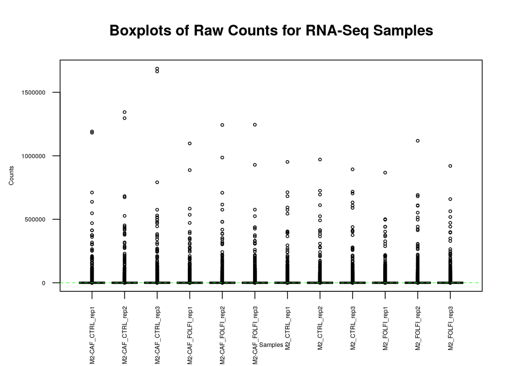

```r
boxplot(mc_seq_data_accessed,
        xlab = "Samples",
        ylab = "Counts",
        las = 2,
        cex = 0.5,
        cex.lab = 0.5,
        cex.axis = 0.5,
        main = "Boxplots of Raw Counts for RNA-Seq Samples",
        col = rainbow(ncol(mc_seq_data_accessed)),
        border = "black")
abline(h = median(apply(mc_seq_data_accessed, 2, median)),
       col = "green", lwd = 0.6, lty = "dashed")
```

All samples in the dataset are grouped and summarized.

```r
list_of_samples <- gse@gsms
samples_type <- do.call(rbind,
                        lapply(list_of_samples,
                          FUN=function(x){
                          c(x@header$title,
                          x@header$characteristics_ch1)
                          }
                        )
                      )
```

```r
colnames(samples_type) <- c("title", "tumor source tissue", "genotype","treatment")
samples_type[,'tumor source tissue'] <- gsub(samples_type[,'tumor source tissue'],
                                pattern = "cell type: ",
                                replacement = "")
samples_type[,'genotype'] <- gsub(
                            samples_type[,'genotype'],
                            pattern = "genotype: ",
                            replacement = "")
samples_type[,'treatment'] <- gsub(
                              samples_type[,'treatment'],
                              pattern = "treatment: ",
                              replacement = "")
kable(samples_type, format = "html")
```

|  | title | tumor source tissue | genotype | treatment |
| --- | --- | --- | --- | --- |
| GSM7075621 | M2 macrophages replicate_1 | Human healthy blood donor monocytes-derived macrophages | WT | M2 macrophages control |
| GSM7075622 | M2 macrophages replicate_2 | Human healthy blood donor monocytes-derived macrophages | WT | M2 macrophages control |
| GSM7075623 | M2 macrophages replicate_3 | Human healthy blood donor monocytes-derived macrophages | WT | M2 macrophages control |
| GSM7075624 | M2 macrophages in coculture with CAFs replicate_1 | Human healthy blood donor monocytes-derived macrophages | WT | M2 macrophages in coculture with CAFs |
| GSM7075625 | M2 macrophages in coculture with CAFs replicate_2 | Human healthy blood donor monocytes-derived macrophages | WT | M2 macrophages in coculture with CAFs |
| GSM7075626 | M2 macrophages in coculture with CAFs replicate_3 | Human healthy blood donor monocytes-derived macrophages | WT | M2 macrophages in coculture with CAFs |
| GSM7075627 | M2 macrophages in coculture with CAFs and treated with Folfirinox replicate_1 | Human healthy blood donor monocytes-derived macrophages | WT | M2 macrophages in coculture with CAFs and treated with Folfirinox |
| GSM7075628 | M2 macrophages in coculture with CAFs and treated with Folfirinox replicate_2 | Human healthy blood donor monocytes-derived macrophages | WT | M2 macrophages in coculture with CAFs and treated with Folfirinox |
| GSM7075629 | M2 macrophages in coculture with CAFs and treated with Folfirinox replicate_3 | Human healthy blood donor monocytes-derived macrophages | WT | M2 macrophages in coculture with CAFs and treated with Folfirinox |
| GSM7075630 | M2 macrophages treated with Folfirinox replicate_1 | Human healthy blood donor monocytes-derived macrophages | WT | M2 macrophages treated with Folfirinox |
| GSM7075631 | M2 macrophages treated with Folfirinox replicate_2 | Human healthy blood donor monocytes-derived macrophages | WT | M2 macrophages treated with Folfirinox |
| GSM7075632 | M2 macrophages treated with Folfirinox replicate_3 | Human healthy blood donor monocytes-derived macrophages | WT | M2 macrophages treated with Folfirinox |

### 3 – Map …

Now we conduct identifier mappings. First, we get rid of the version number associated with our ENSEMBL ids.

```r
mc_seq_matrix <- as.matrix(mc_seq_data_accessed)
rownames(mc_seq_matrix) <- unlist(lapply(rownames(mc_seq_matrix),
                                             FUN=function(x){unlist(strsplit(x,split = "\\."))[1]}))
kable(mc_seq_matrix[1:5, 1:5],format="html")
```

|  | M2-CAF_CTRL_rep1 | M2-CAF_CTRL_rep2 | M2-CAF_CTRL_rep3 | M2-CAF_FOLFI_rep1 | M2-CAF_FOLFI_rep2 |
| --- | --- | --- | --- | --- | --- |
| ENSG00000223972 | 0 | 0 | 0 | 0 | 0 |
| ENSG00000227232 | 75 | 91 | 103 | 86 | 95 |
| ENSG00000278267 | 1 | 1 | 1 | 2 | 1 |
| ENSG00000243485 | 0 | 0 | 0 | 0 | 0 |
| ENSG00000284332 | 0 | 0 | 0 | 0 | 0 |

There are 44 duplicated Ensembl IDs. Since they will be mapped to same HUGO gene symbols, we will deal with them downstream after mapping.

```r
sum(duplicated(rownames(mc_seq_matrix)))
```

```
## [1] 44
```

Since the original dataset used Ensembl ids, it is best to use Ensembl database for mapping HUGO gene symbols. Connect to Ensembl Biomart database using biomaRt package [5]. The dataset specific for human is selected.

```r
ensembl <- useMart("ensembl")
ensembl <- useDataset("hsapiens_gene_ensembl",mart=ensembl)
```

Obtain the Ensembl Ids to convert.

```r
ids2convert <- rownames(mc_seq_matrix)
```

The conversion table is loaded through querying Ensembl.

```r
conversion_stash <- "id_conversion.rds"
if(file.exists(conversion_stash)){
  id_conversion <- readRDS(conversion_stash)
} else {
  id_conversion <- getBM(attributes =
  c("ensembl_gene_id","hgnc_symbol"),
  filters = c("ensembl_gene_id"),
  values = ids2convert,
  mart = ensembl)
  saveRDS(id_conversion, conversion_stash)
}
```

Some of the ensembl_gene_id in id_conversion are paired empty hgnc_symbol, it conveys no information so we want to remove them for downstream processing.

```r
id_conversion <- id_conversion %>%
    filter(hgnc_symbol!="")
```

We convert the matrix to dataframe for easier processing

```r
mc_seq_df <- as.data.frame(mc_seq_matrix)
mc_seq_df$ensembl_gene_id <- rownames(mc_seq_df)
```

The expression values ensembl ids that are found in the conversion table.

```r
length(which(rownames(mc_seq_matrix) %in% id_conversion$ensembl_gene_id))
```

```
## [1] 41009
```

The expression values or ensembl ids that are not found in the conversion table.

```r
nrow(mc_seq_matrix) - length(which(rownames(mc_seq_matrix) %in% id_conversion$ensembl_gene_id))
```

```
## [1] 19651
```

The dataframe is annotated with hgnc symbol.

```r
mc_seq_matrix_annot <- merge(id_conversion,
                                 mc_seq_matrix,
                                 by.x = 1,
                                 by.y = 0, all.y=TRUE)
kable(mc_seq_matrix_annot[1:5,1:5],type = "html")
```

| ensembl_gene_id | hgnc_symbol | M2-CAF_CTRL_rep1 | M2-CAF_CTRL_rep2 | M2-CAF_CTRL_rep3 |
| --- | --- | --- | --- | --- |
| ENSG00000000003 | TSPAN6 | 6 | 14 | 2 |
| ENSG00000000005 | TNMD | 0 | 0 | 0 |
| ENSG00000000419 | DPM1 | 892 | 816 | 1327 |
| ENSG00000000457 | SCYL3 | 363 | 342 | 416 |
| ENSG00000000460 | FIRRM | 91 | 104 | 158 |

The number of rows in the matrix is 60663, which is greater than original 60660 rows suggest that some ensembl gene IDs in id_conversion map to multiple rows in mc_seq_matrix. This is expected as there are duplicates in ensembl gene IDs in both id_conversion and mc_seq_matrix

```r
sum(duplicated(id_conversion$ensembl_gene_id))
```

```
## [1] 3
```

```r
sum(duplicated(rownames(mc_seq_matrix)))
```

```
## [1] 44
```

```r
nrow(mc_seq_matrix_annot)
```

```
## [1] 60663
```

19688 rows in the matrix do not have matching hgnc_symbol.

```r
ensembl_id_missing_gene <- mc_seq_matrix_annot %>%
  filter(is.na(hgnc_symbol)) %>%
  pull(ensembl_gene_id)
length(ensembl_id_missing_gene)
```

```
## [1] 19688
```

```r
kable(mc_seq_matrix_annot[
  which(is.na(mc_seq_matrix_annot$hgnc_symbol))[1:5],1:5],
  type="html")
```

[output not shown]

The genes with no hgnc_symbol are removed.

```r
mc_seq_matrix_annot <- mc_seq_matrix_annot %>%
  filter(!is.na(hgnc_symbol))
length(mc_seq_matrix_annot$hgnc_symbol)
```

```
## [1] 40975
```

There are 3 rows that have duplicated ensembl_gene_ids.

```r
sum(duplicated(mc_seq_matrix_annot$ensembl_gene_id))
```

```
## [1] 3
```

```r
duplicated_ensembl <- mc_seq_matrix_annot %>%
    filter(ensembl_gene_id %in% ensembl_gene_id[duplicated(ensembl_gene_id)])
kable(duplicated_ensembl[1:5, 1:5], format="html")
```

| ensembl_gene_id | hgnc_symbol | M2-CAF_CTRL_rep1 | M2-CAF_CTRL_rep2 | M2-CAF_CTRL_rep3 |
| --- | --- | --- | --- | --- |
| ENSG00000230417 | LINC00595 | 2 | 4 | 6 |
| ENSG00000230417 | LINC00856 | 2 | 4 | 6 |
| ENSG00000280739 | EIF1B-AS1 | 139 | 160 | 165 |
| ENSG00000280739 | ENTPD3-AS1 | 139 | 160 | 165 |
| ENSG00000286061 | NCMAP-DT | 2 | 0 | 5 |

```r
mc_seq_matrix_annot <- mc_seq_matrix_annot %>%
  filter(!(ensembl_gene_id == "ENSG00000230417" & hgnc_symbol == "LINC00856")) %>%
  filter(!(ensembl_gene_id == "ENSG00000280739" & hgnc_symbol == "ENTPD3-AS1")) %>%
  filter(!(ensembl_gene_id == "ENSG00000286061" & hgnc_symbol == "RCAN3AS"))
```

Now, we handle the case where multiple identifiers that map to same hgnc_symbol. There are 18 rows that have duplicated symbols.

```r
sum(duplicated(mc_seq_matrix_annot$hgnc_symbol))
```

```
## [1] 18
```

```r
duplicated_hgnc <- mc_seq_matrix_annot %>%
    filter(hgnc_symbol %in% hgnc_symbol[duplicated(hgnc_symbol)])
kable(duplicated_hgnc[1:5, 1:5], format="html")
```

| ensembl_gene_id | hgnc_symbol | M2-CAF_CTRL_rep1 | M2-CAF_CTRL_rep2 | M2-CAF_CTRL_rep3 |
| --- | --- | --- | --- | --- |
| ENSG00000105501 | SIGLEC5 | 53 | 71 | 65 |
| ENSG00000149531 | FRG1BP | 87 | 86 | 122 |
| ENSG00000168255 | POLR2J3 | 127 | 116 | 110 |
| ENSG00000188626 | GOLGA8M | 0 | 0 | 3 |
| ENSG00000197332 | ZNF833P | 0 | 0 | 0 |

```r
mc_seq_matrix_annot <- mc_seq_matrix_annot %>% dplyr::select(-ensembl_gene_id)
duplicate_genes <- mc_seq_matrix_annot %>% count(hgnc_symbol) %>% filter(n > 1) %>% pull(hgnc_symbol)
```

The duplicated symbols are solved. Row with the same symbol are combined to 1 row with the count value being the average of all duplicated rows.

```r
dup_rows <- mc_seq_matrix_annot %>% filter(hgnc_symbol %in% duplicate_genes)
unique_rows <- mc_seq_matrix_annot %>% filter(!hgnc_symbol %in% duplicate_genes)
agg_dup_rows <- dup_rows %>%
  group_by(hgnc_symbol) %>%
  summarise(across(where(is.numeric), \(x) mean(x, na.rm = TRUE)), .groups = "drop")
final_mc_seq_df_annot <- bind_rows(unique_rows, agg_dup_rows)
```

We shrink our dataset into the mapped matrix with HUGO symbols that contains 40954 rows, with no duplicated HUGO symbols

```r
mc_matrix_mapped <- final_mc_seq_df_annot %>% dplyr::select(-hgnc_symbol) %>% as.matrix()
rownames(mc_matrix_mapped) <- final_mc_seq_df_annot$hgnc_symbol
dim(mc_matrix_mapped)
```

```
## [1] 40954    12
```

```r
sum(duplicated(rownames(mc_matrix_mapped)))
```

```
## [1] 0
```

The resulting mapped matrix looks like this.

```r
kable(mc_matrix_mapped[1:5, 1:5], format="html")
```

|  | M2-CAF_CTRL_rep1 | M2-CAF_CTRL_rep2 | M2-CAF_CTRL_rep3 | M2-CAF_FOLFI_rep1 | M2-CAF_FOLFI_rep2 |
| --- | --- | --- | --- | --- | --- |
| TSPAN6 | 6 | 14 | 2 | 10 | 12 |
| TNMD | 0 | 0 | 0 | 0 | 0 |
| DPM1 | 892 | 816 | 1327 | 819 | 984 |
| SCYL3 | 363 | 342 | 416 | 370 | 448 |
| FIRRM | 91 | 104 | 158 | 100 | 84 |

### 4 – Clean …

Next step, We need to get rid of genes with low counts! We first look into the distribution of each sample before filtering for outliers.

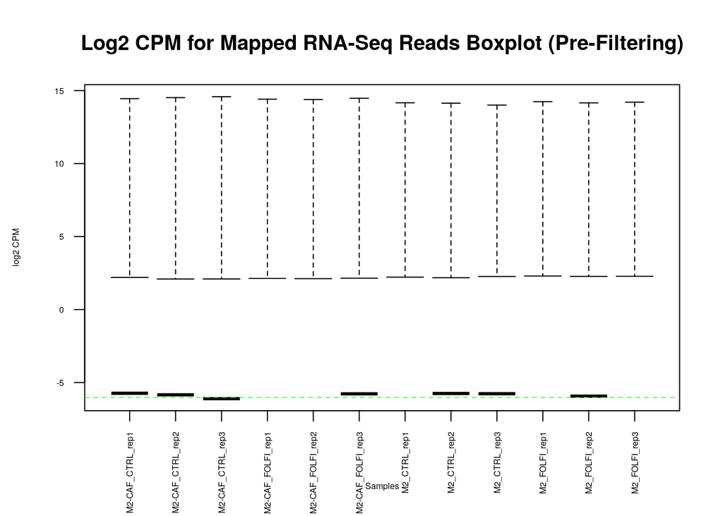

```r
data2plot <- log2(cpm(mc_matrix_mapped)) # add 1 to avoid log2(0)
boxplot(data2plot,
        xlab = "Samples",
        ylab = "log2 CPM",
        las = 2, cex = 0.5, cex.lab = 0.5,
        cex.axis = 0.5,
        main = "Log2 CPM for Mapped RNA-Seq Reads Boxplot (Pre-Filtering)")
        #draw the median on each box plot
        abline(h = median(apply(data2plot, 2, median)),
               col = "green", lwd = 0.6, lty = "dashed")
```

The density plot for the unfiltered dataset. It seems that it follows a bimodal distribution with 2 peak.

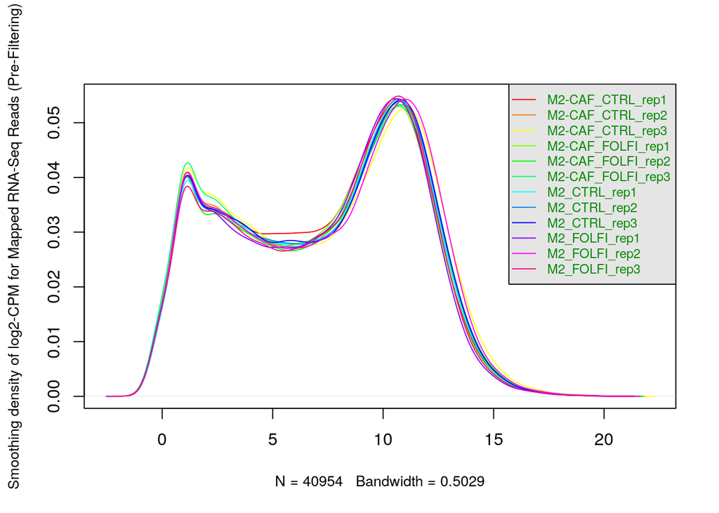

```r
counts_density <- apply(log2(mc_matrix_mapped), 2, density)
xlim <- 0; ylim <- 0
for (i in 1:length(counts_density)) {
xlim <- range(c(xlim, counts_density[[i]]$x));
ylim <- range(c(ylim, counts_density[[i]]$y))
}
cols <- rainbow(length(counts_density))
ltys <- rep(1, length(counts_density))
plot(counts_density[[1]], xlim=xlim, ylim=ylim, type="n",
ylab="Smoothing density of log2-CPM for Mapped RNA-Seq Reads (Pre-Filtering)",
main="", cex.lab = 0.85)
for (i in 1:length(counts_density))
lines(counts_density[[i]], col=cols[i], lty=ltys[i])
legend("topright", colnames(data2plot),
col=cols, lty=ltys, cex=0.75,
border ="blue", text.col = "green4",
merge = TRUE, bg = "gray90")
```

We then look into the minimal number of samples. Since there are 3 samples for each conditions, we choose 3 samples as the minimal number of samples.

```r
samples_type_dt <- data.table::data.table(samples_type)
kable(samples_type_dt[, .(count = .N), by = samples_type_dt$treatment ], format="html")
```

| samples_type_dt | count |
| --- | --- |
| M2 macrophages control | 3 |
| M2 macrophages in coculture with CAFs | 3 |
| M2 macrophages in coculture with CAFs and treated with Folfirinox | 3 |
| M2 macrophages treated with Folfirinox | 3 |

We remove the genes with low counts based on the minimal number of samples, based on the recommendation by edgeR [2].

```r
min_num_samples <- 3
keep = rowSums(cpm(mc_matrix_mapped) >1) > min_num_samples
mc_matrix_mapped_filtered = mc_matrix_mapped[keep,]
```

The number of genes in our dataset went from 40954 to 13121 after removing low counts.

```r
dim(mc_matrix_mapped)[1]
```

```
## [1] 40954
```

```r
dim(mc_matrix_mapped_filtered)[1]
```

```
## [1] 13121
```

We then plot the density and distribution plot after the filtering. The first peak seems to be smoothed out in the density plot and the boxplots for each sample shows that the majority of the count values are higher.

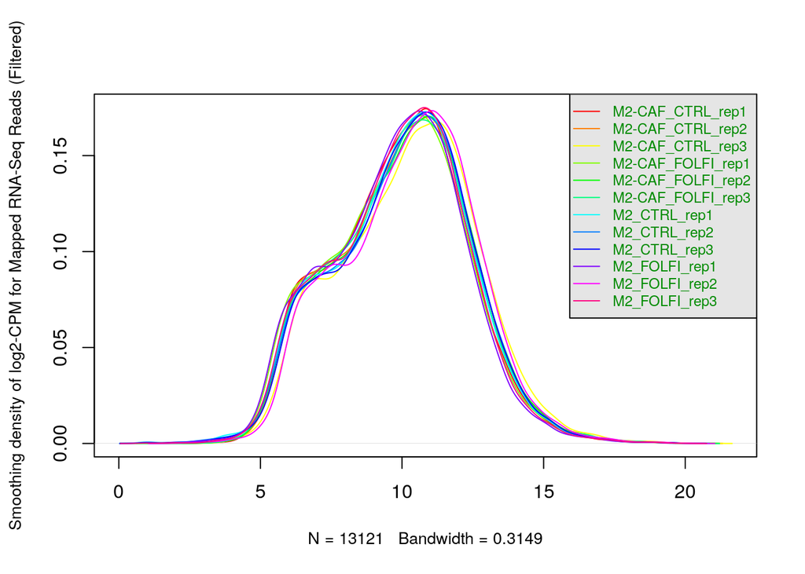

```r
counts_density <- apply(log2(mc_matrix_mapped_filtered), 2, density)
#calculate the limits across all the samples
xlim <- 0; ylim <- 0
for (i in 1:length(counts_density)) {
  xlim <- range(c(xlim, counts_density[[i]]$x));
  ylim <- range(c(ylim, counts_density[[i]]$y))
}
cols <- rainbow(length(counts_density))
ltys <- rep(1, length(counts_density))
#plot the first density plot to initialize the plot
plot(counts_density[[1]],
     xlim=xlim, ylim=ylim, type="n",
     ylab="Smoothing density of log2-CPM for Mapped RNA-Seq Reads (Filtered)",
     main="", cex.lab = 0.85)
#plot each line
for (i in 1:length(counts_density))
  lines(counts_density[[i]], col=cols[i], lty=ltys[i])
  #create legend
  legend("topright", colnames(data2plot),
  col=cols, lty=ltys, cex=0.75,
  border ="blue", text.col = "green4",
  merge = TRUE, bg = "gray90")
```

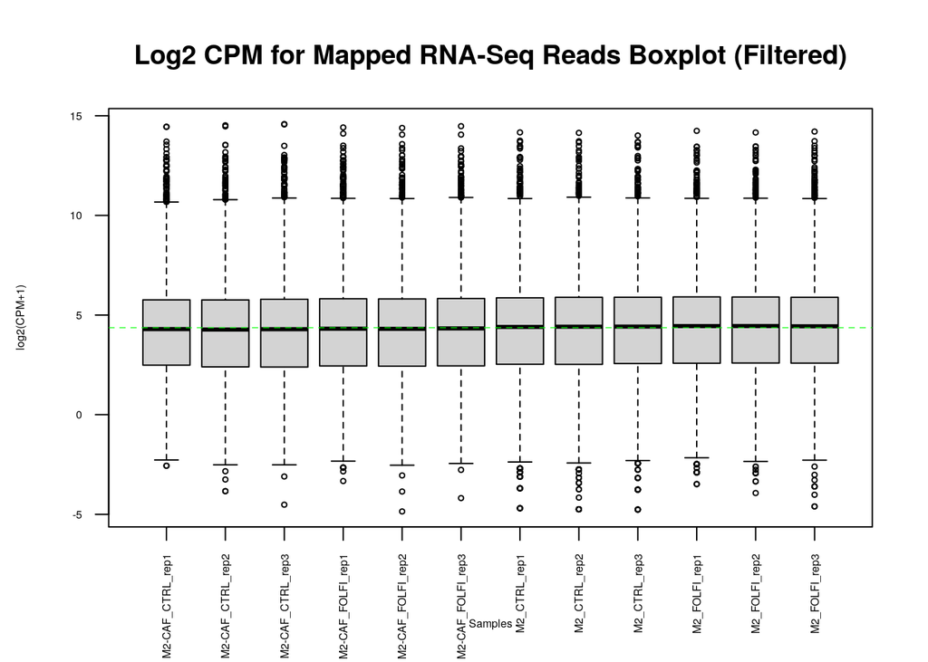

```r
data2plot <- log2(cpm(mc_matrix_mapped_filtered)) # add 1 to avoid log2(0)
boxplot(data2plot,
        xlab = "Samples",
        ylab = "log2(CPM+1)",
        las = 2, cex = 0.5, cex.lab = 0.5,
        cex.axis = 0.5,
        main = "Log2 CPM for Mapped RNA-Seq Reads Boxplot (Filtered)")
        #draw the median on each box plot
        abline(h = median(apply(data2plot, 2, median)),
               col = "green", lwd = 0.6, lty = "dashed")
```

## Apply Normalization

First we create the groups of our datasets.

```r
sample_names <- colnames(mc_matrix_mapped_filtered)
groups <- factor(gsub("_rep[0-9]+", "", sample_names))
groups
```

```
##  [1] M2-CAF_CTRL  M2-CAF_CTRL  M2-CAF_CTRL  M2-CAF_FOLFI M2-CAF_FOLFI
##  [6] M2-CAF_FOLFI M2_CTRL      M2_CTRL      M2_CTRL      M2_FOLFI
## [11] M2_FOLFI     M2_FOLFI
## Levels: M2_CTRL M2_FOLFI M2-CAF_CTRL M2-CAF_FOLFI
```

We then obtain the normalized RNA-Seq count data, by applying TMM to our dataset using EdgeR [2].

```r
d_data = DGEList(counts=mc_matrix_mapped_filtered, group=groups)
d_data = calcNormFactors(d_data)
mc_matrix_normalized <- cpm(d_data)
```

We plot the density plot for the noramalized counts. The density plots for all sample seem to be more centered and less spread out and the boxplot does not show a huge difference as the median is already roughly centered before the normalization.

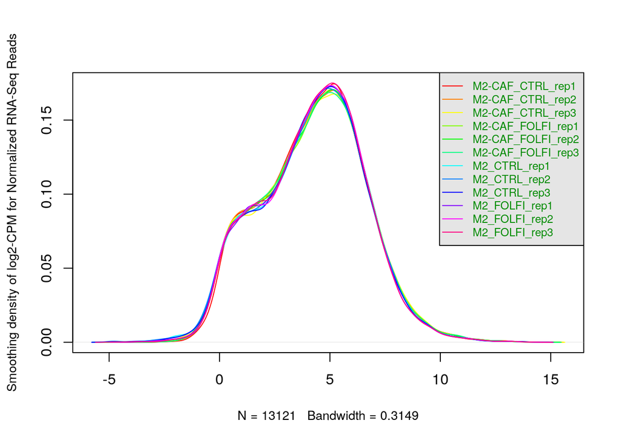

```r
counts_density <- apply(log2(mc_matrix_normalized), 2, density)
xlim <- 0; ylim <- 0
for (i in 1:length(counts_density)) {
xlim <- range(c(xlim, counts_density[[i]]$x));
ylim <- range(c(ylim, counts_density[[i]]$y))
}
cols <- rainbow(length(counts_density))
ltys <- rep(1, length(counts_density))
plot(counts_density[[1]], xlim=xlim, ylim=ylim, type="n",
ylab="Smoothing density of log2-CPM for Normalized RNA-Seq Reads",
main="", cex.lab = 0.85)
for (i in 1:length(counts_density))
lines(counts_density[[i]], col=cols[i], lty=ltys[i])
legend("topright", colnames(data2plot),
col=cols, lty=ltys, cex=0.75,
border ="blue", text.col = "green4",
merge = TRUE, bg = "gray90")
```

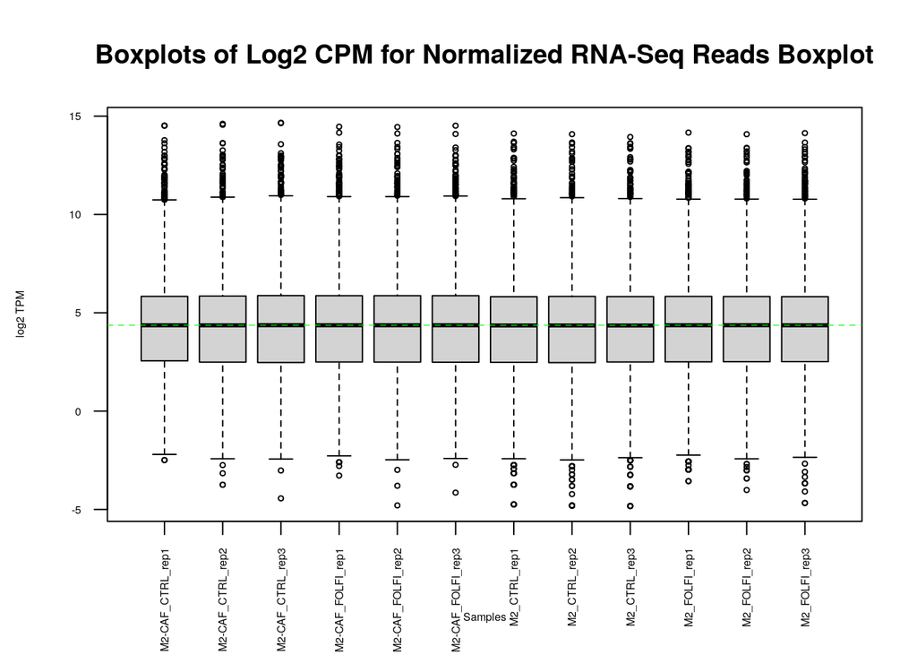

```r
data2plot <- log2(mc_matrix_normalized)
  boxplot(data2plot, xlab = "Samples", ylab = "log2 TPM",
  las = 2, cex = 0.5, cex.lab = 0.5,
  cex.axis = 0.5, main = "Boxplots of Log2 CPM for Normalized RNA-Seq Reads Boxplot")
  abline(h = median(apply(data2plot, 2, median)),
  col = "green", lwd = 0.6, lty = "dashed")
```

The MDS plot shows that the samples from different group are well seperated [1]. Given that the sample are from human derived cell line samples, it should be expected and it would be less noisy as the patient RNA seq as shown in the lecture.

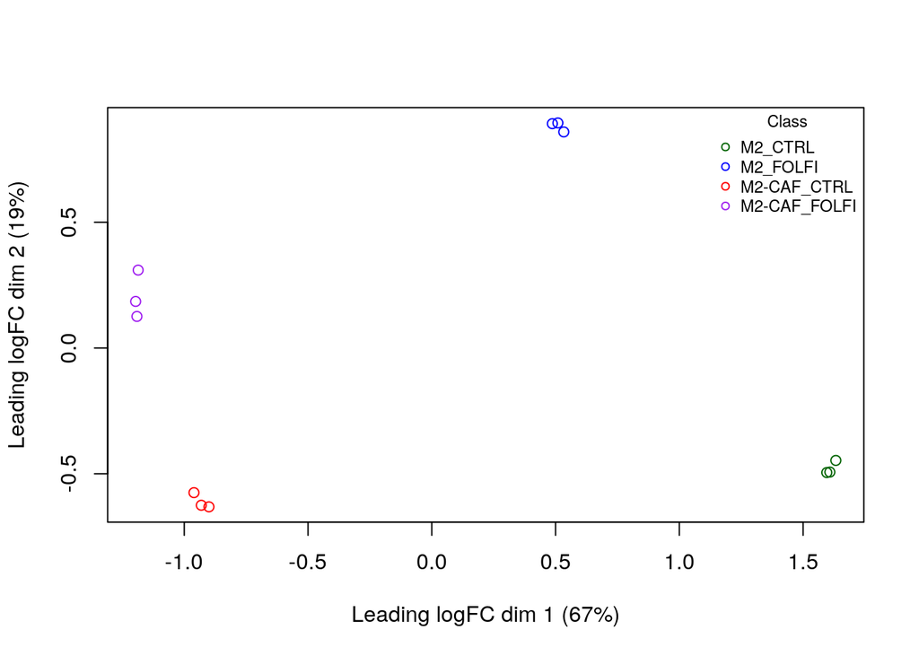

```r
plotMDS(d_data, labels=NULL, pch = 1,
               col = c("darkgreen","blue", "red", "purple")[factor(groups)])
legend("topright",
       legend=levels(factor(groups)),
       pch=c(1), col= c("darkgreen","blue","red", "purple"),title="Class",
       bty = 'n', cex = 0.75)
```

We then calculate dispersion to assess the quality of the normalized dataset.

```r
d_data <- calcNormFactors(d_data)
model_design <- model.matrix(~groups)
d_data <- estimateDisp(d_data, model_design)
```

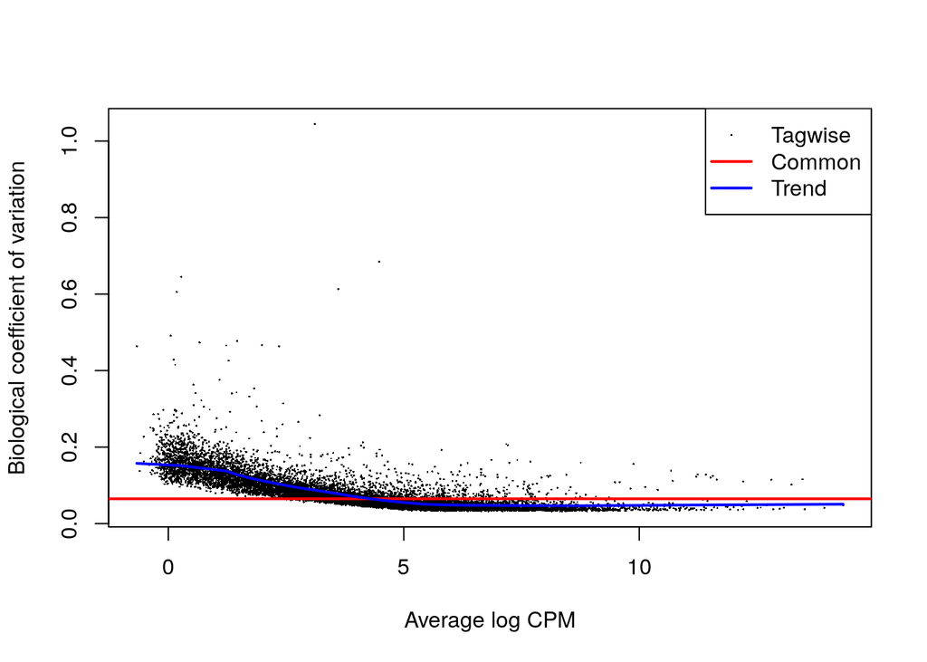

```r
plotBCV(d_data, col.tagwise="black", col.common = "red",)
```

We then look into the mean variance relationship of our dataset. The dataset doesn’t follow the black line representing poisson distribution strictly, which is expected in RNA seq dataset.

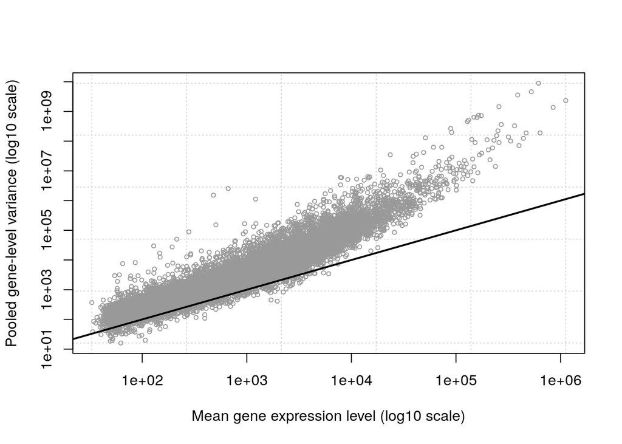

```r
plotMeanVar(d_data,
            show.raw.vars = TRUE,
            show.tagwise.vars=FALSE,
            NBline=FALSE,
            show.ave.raw.vars = FALSE,
            show.binned.common.disp.vars = FALSE
            )
```

We got tighter distribution if we use tagwise variance, which measure gene-specific dispersion, indicating it is a more stable estimate.

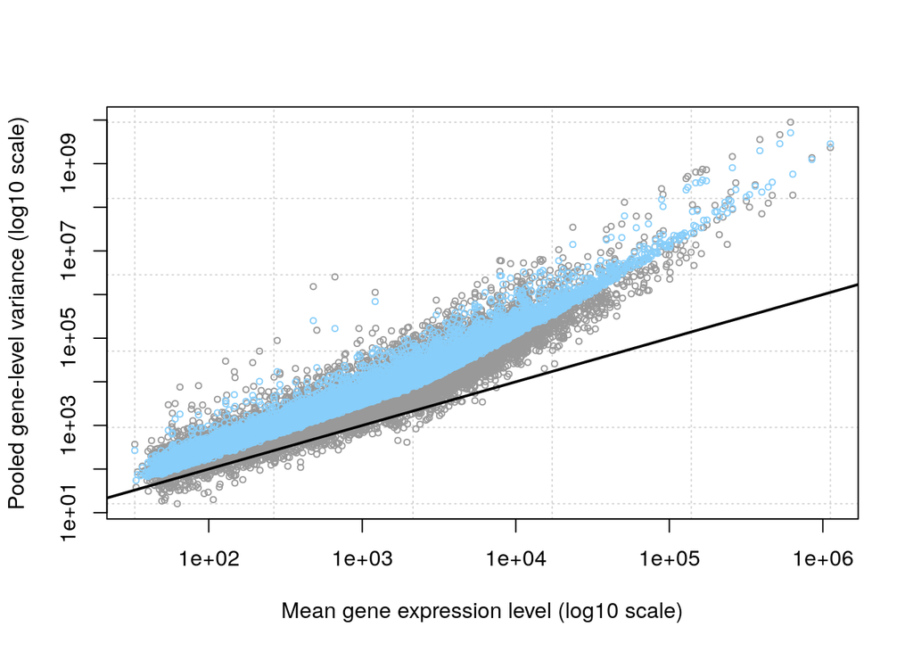

```r
plotMeanVar(d_data,
            show.raw.vars = TRUE,
            show.tagwise.vars=TRUE,
            NBline=FALSE,
            show.ave.raw.vars = FALSE,
            show.binned.common.disp.vars = FALSE
            )
```

The raw variance from the dataset (shown in dark red) are similiar with the adjusted variance, indicating that the dataset is naturally well-behaved.

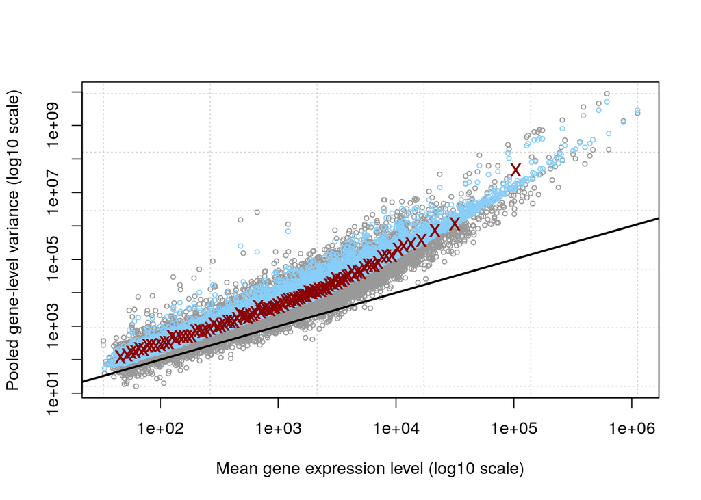

```r
plotMeanVar(d_data,
            show.raw.vars = TRUE,
            show.tagwise.vars=TRUE,
            NBline=FALSE,
            show.ave.raw.vars = TRUE,
            show.binned.common.disp.vars = FALSE
            )
```

The dataset also fit the binned common dispersion line well it suggest that the dataset follows a common dispersion model well.

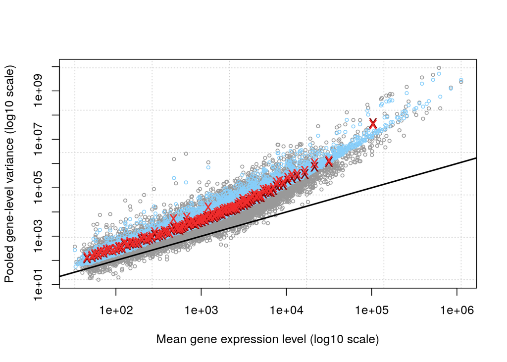

```r
plotMeanVar(d_data,
            show.raw.vars = TRUE,
            show.tagwise.vars = TRUE,
            NBline = FALSE,
            show.ave.raw.vars = TRUE,
            show.binned.common.disp.vars = TRUE)
```

The dataset is well fitted to the negative binomial (NB) variance trend line which satisfy the assumption of edgeR [2].

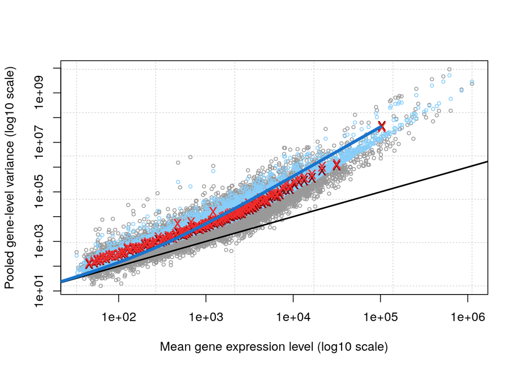

```r
plotMeanVar(d_data,
            show.raw.vars = TRUE,
            show.tagwise.vars=TRUE,
            show.ave.raw.vars = TRUE,
            NBline=TRUE,
            show.binned.common.disp.vars = TRUE)
```

We then save the normalized dataset to the output

```r
df <- as.data.frame(mc_matrix_normalized)
kable(df[1:5, 1:5], format="html")
```

|  | M2-CAF_CTRL_rep1 | M2-CAF_CTRL_rep2 | M2-CAF_CTRL_rep3 | M2-CAF_FOLFI_rep1 | M2-CAF_FOLFI_rep2 |
| --- | --- | --- | --- | --- | --- |
| DPM1 | 17.626987 | 15.208069 | 20.434383 | 16.888989 | 17.708892 |
| SCYL3 | 7.173314 | 6.373970 | 6.405956 | 7.629946 | 8.062585 |
| FIRRM | 1.798269 | 1.938283 | 2.433031 | 2.062148 | 1.511735 |
| FGR | 337.363133 | 354.948135 | 330.245501 | 342.460846 | 345.071446 |
| CFH | 2.667761 | 3.280172 | 3.557153 | 3.051978 | 3.689353 |

```r
write.table(df,
            file.path(getwd(), data_geoid,
                      paste(data_geoid, "normalized_filtered_counts.txt", sep = "_")),
            quote = FALSE, sep = "\t", row.names = TRUE, col.names = NA)
```

## Interpret and Document

**Why is the dataset of interest to you?** I choose this dataset because I want to look into pancreatic ductal adenocarcinoma (PDAC) from transcriptomic perspective as I am working on PDAC in my other thesis course (BCB330). PDAC is also one of the deadliest cancer with five year survival rate of less than 10% [10].

**What are the control and test conditions of the dataset?** The control condition is the healthy human donor macrophage and the test conditions are the macrophage coculture with human PDAC CAFs, macrophages in coculture with human PDAC CAFs with Folfirinox treatment, and macrophages treated with Folfirinox.

**How many samples in each of the conditions of your dataset?** There are 3 samples in each of the conditions of my dataset.

**Were there expression values that were not unique for specific genes? How did you handle these?** There were 44 duplicated Ensemble IDs that were not unique for specific genes. I didn’t handle it on the spot but instead I choose to do downstream after mapping to HGNC symbol. As the same Ensemble ID will be mapped to the same HGNC symbol, I removed the duplicated HGNC symbols downstream at once.

**Were there expression values that could not be mapped to current HUGO symbols?** Yes, there were 19651 expression values that could not be mapped to current HUGO symbols.

*How did you handle replicates?* There are no technical replicates are all samples are the same run. However, there are biological replicates as they are 3 samples in each conditions. I am handling it by group them into the same group in further analysis.

*What is the final coverage of your dataset?* The final coverage of my dataset is around 13121 genes with normalized counts.

1. Ritchie ME, Phipson B, Wu D, Hu Y, Law CW, Shi W, et al. Limma powers differential expression analyses for RNA-sequencing and microarray studies. Nucleic acids research. 2015;43:e47–7.

2. Robinson MD, McCarthy DJ, Smyth GK. edgeR: A bioconductor package for differential expression analysis of digital gene expression data. bioinformatics. 2010;26:139–40.

3. Xie Y. Knitr: A comprehensive tool for reproducible research in r. In: Implementing reproducible research. Chapman; Hall/CRC; 2018. p. 3–31.

4. Villanueva RAM, Chen ZJ. ggplot2: Elegant graphics for data analysis. 2019.

5. Durinck S, Spellman PT, Birney E, Huber W. Mapping identifiers for the integration of genomic datasets with the r/bioconductor package biomaRt. Nature protocols. 2009;4:1184–91.

6. Davis S, Meltzer PS. GEOquery: A bridge between the gene expression omnibus (GEO) and BioConductor. Bioinformatics. 2007;23:1846–7.

7. Hussain Z, Bertran T, Finetti P, Lohmann E, Mamessier E, Bidaut G, et al. Macrophages reprogramming driven by cancer-associated fibroblasts under FOLFIRINOX treatment correlates with shorter survival in pancreatic cancer. Cell Communication and Signaling. 2024;22:1.

8. Edgar R, Domrachev M, Lash AE. Gene expression omnibus: NCBI gene expression and hybridization array data repository. Nucleic acids research. 2002;30:207–10.

9. Seal RL, Braschi B, Gray K, Jones TE, Tweedie S, Haim-Vilmovsky L, et al. Genenames. Org: The HGNC resources in 2023. Nucleic Acids Research. 2023;51:D1003–9.

10. Sarantis P, Koustas E, Papadimitropoulou A, Papavassiliou AG, Karamouzis MV. Pancreatic ductal adenocarcinoma: Treatment hurdles, tumor microenvironment and immunotherapy. World journal of gastrointestinal oncology. 2020;12:173.